# Flashiness

# Discussion(2)

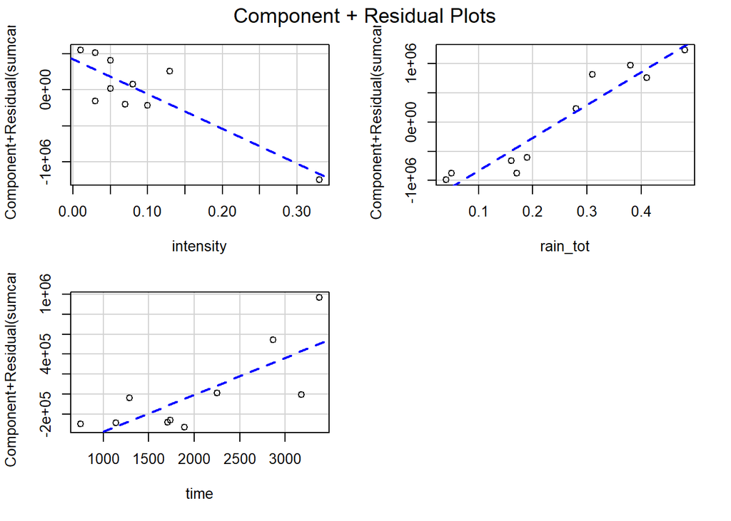

```r
crPlots(storm_mlr, smooth = FALSE)
```

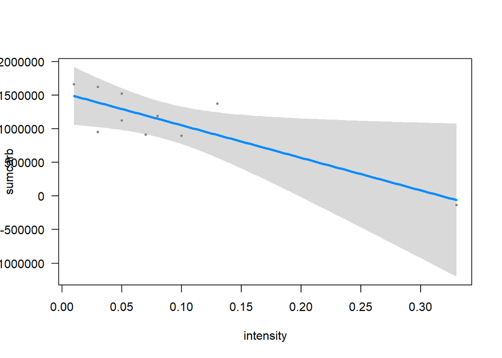

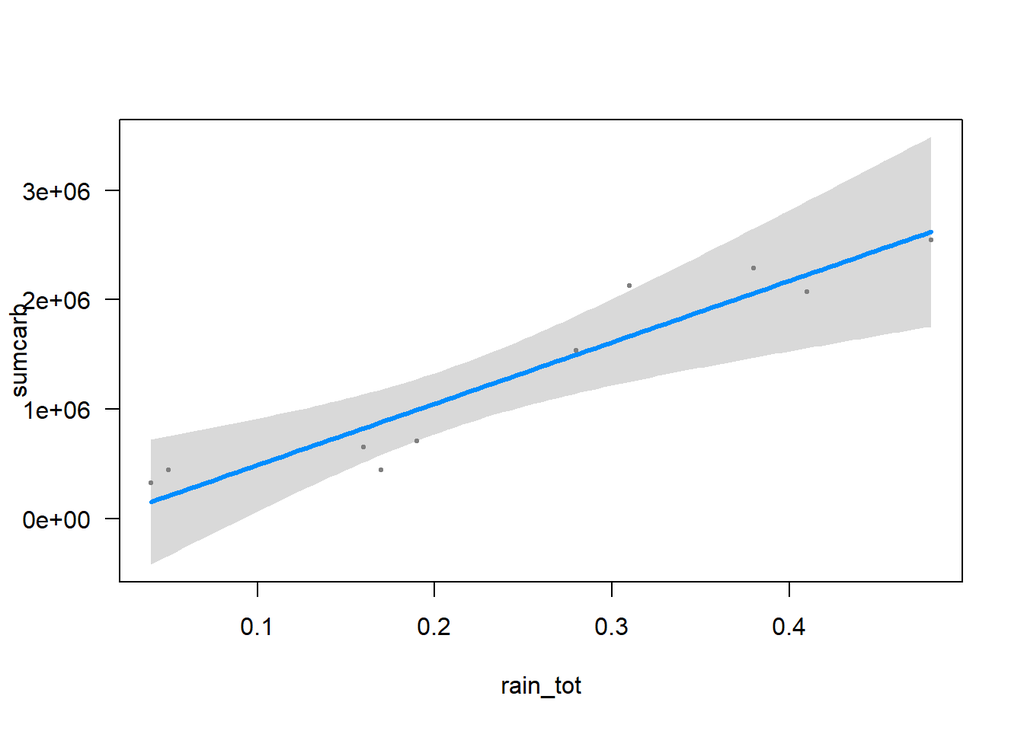

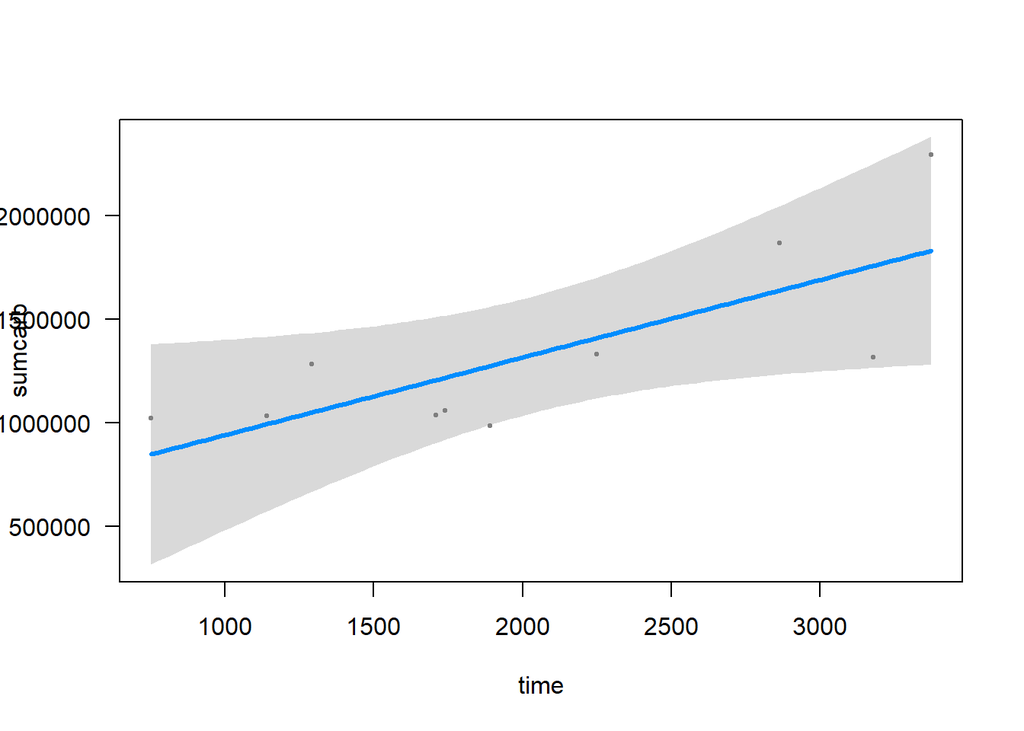

```r
visreg(storm_mlr)
```

The above graphs show that carbon is affected positivly by rain total and time and negativly by intensity.

# Conclusion(2)

We can see from this model that carbon totals during storms are highly correlated to storm factors (total, intesity, time).

Future work include getting more storms and more rivers. I had a sample size of 10 storms with ultimatly more than 3 parameters. This means I need many more data point to have an accurate model. I also had one outlier with a high intensity. I need to sample more storms with high intensity.

All this being said, this is a great start to a more compex and complete model of my system.